# **Data Analysis: Assignment 1**

#### *Tidied by: Franco Anderson (21675910) & Juan Möller (21597340)*

## Table of Contents

| SECTION | TITLE |
| --- | --- |
| Section 1 | Introduction |
| Section 1 | Package and library imports |
| Section 1 | Data imports |
| Section 2 | Plots and discussion |
| Section 3 | Reflection |
| Section 3 | Conclusion |

# **Section 1**

## Introduction

The following RMD notebook contains information, data, and visualizations relating to the first assignment of the data analysis block. Assignment one required the accurate reproduction of COVID-19 visualizations as shown on the [Media Hack](https://mediahack.co.za/datastories/coronavirus/dashboard/) website using Rstudio. Apart from the colours used by Media Hack, all other visual aspects of the plots were reproduced as far as possible. A particular focus was also placed on producing a logical and coherent document which can be easily read and understood by anyone.

The notebook is divided into three unique sections, each focusing on specific parts of the assignment. Section one includes relevant information on the R packages used to assist in the process of wrangling and processing data as well as producing good visualizations. It also contains information on our data sources and the methods used to retrieve the data. Section two contains the main part of the assignment – the code for processing data and visualizations – and discussions on the various plots. Section three includes our retrospective section and, finally, the conclusion.

## Package and library imports

These packages have been commented out. If this project is to be run for the first time, the comments are to be removed and the chunk should be run.

```r
#install.packages("tidyverse")
#install.packages("gglot2")
#install.packages("zoo")
#install.packages("scales")
#install.packages("rnaturalearthdata")  #Bonus
#install.packages("rgeos")              #Bonues
```

These libraries are essential for the code to work. This chunk should be run once.

```r
library(tidyverse)
library(dplyr)
library(ggplot2)
library(zoo)            #rollmean
library(scales)
library(rnaturalearth)  #Bonus
library(rgeos)          #Bonus
```

## Data imports

The following chunk contains information on the location of the data used to produce the COVID-19 visualizations. Some of the data used to produce the plots were obtained using screen scraping techniques learnt in the second week of the data analysis block. Where conventional screen scraping techniques did not work, an alternative method using JavaScript was used to convert HTML data tables to CSV files for easier processing on Excel and Rstudio. In total, four sources were used to obtain all of the data used in this notebook. Where possible, data were collected for the period between March 2020 and 22 June 2021.

Data sources: 1.[Media Hack](https://mediahack.co.za/datastories/coronavirus/dashboard/) 2.[OWID](https://ourworldindata.org/coronavirus) 3.[NICD](https://www.nicd.ac.za/diseases-a-z-index/covid-19/surveillance-reports/weekly-hospital-surveillance-datcov-update/) 4.[SAMRC](https://www.samrc.ac.za/reports/report-weekly-deaths-south-africa)

```r
sa_cases <- read_csv("DATA/sa_cases.csv")                      #retrieved with screen scraping
province_data<-read.csv("DATA/province_data.csv")              #retrieved with screen scraping

provincial_tests <- read_csv("DATA/provincial_tests.csv")      #retrieved with screen scraping
excess_deaths<- read.csv("DATA/excess_deaths.csv")             #retrieved from SAMRC

continents_daily_cases <- read_csv("DATA/continents_daily_cases.csv")    #retrieved from OWID
sa_reproduction_rate <- read_csv("DATA/sa_reproduction_rate.csv")        #retrieved from OWID
sa_hospitalisations <- read_csv("DATA/sa_hospitalisations.csv")          #retrieved from NICD
province_data_map<-read.csv("DATA/province_data_map.csv")              #BONUS
```

# **Section 2**

## Plots and discussion

As mentioned in the introduction, all plots were reproduced as accurately as possible using the sourced data and the Media Hack website as a guide. It was only the colours that were changed and applied consistently across all visuals. Plot headings, subheadings, and labels were also matched as far as possible. Each of the visuals below are preceded by a short discussion on the specific plot.

### Plot 1: Daily Vaccinations

The Daily vaccinations plot aims to indicate the daily number of vaccinations within South Africa over a period of time. Thus the date was needed in the correct format to scale it across the x-axis. *A geom_col* visual was chosen as it indicates the level of vaccinations per day while the columns are easily comparable. A clear increase over time is seen indicating an effort to increase vaccinations in the country.

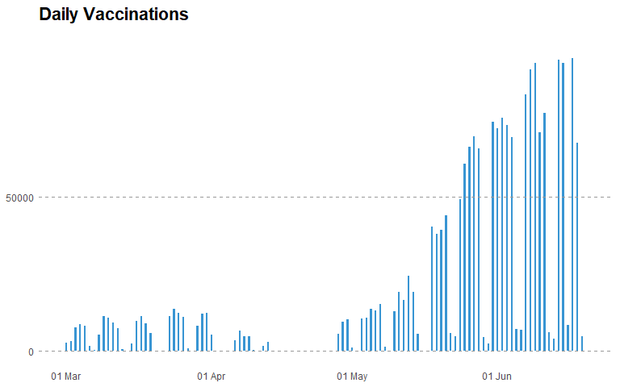

```r
plot_1_table<-sa_cases %>%
  select(date,vaccinated_daily)%>%
  mutate(date=as.Date(date,"%d/%m/%Y"))                         #converting date data to the desired date format

plot_one<-plot_1_table %>% filter(date>=as.Date("2021-03-01") & date<=as.Date("2021-06-21")) %>% #creating new plot
  ggplot(mapping = aes(y=vaccinated_daily,x=date))+
  geom_col(width = 0.4, fill="#3895D3")+
  scale_y_continuous(breaks = c(0,50000), limits = (c(0,100000)))+
  scale_x_date(date_breaks = "1 month",                      #displays one day per month on plot
               date_labels = "%d %b")+                       #displays date in required format on plot
  labs(x="Date", y="Cumulative Cases",                       #add label names to axis
       title="Daily Vaccinations",
       #subtitle = "subtitle",
       #caption = "caption")
       vaccinated_daily = "Legend")+
  geom_hline(yintercept=c(0,50000), linetype="dashed", color="grey60")+
  theme(                                                      #various theme settings
        panel.border = element_blank(),
        panel.background = element_blank(),
        panel.grid = element_blank(),                        #panel.grid.minor & panel.grid.major both removed to comply with mediahack visual
        plot.title = element_text(face="bold",size = rel(1.5)),
        plot.subtitle = element_text(colour = "grey40"),
        axis.title = element_blank(),
        axis.ticks = element_blank()
        )
plot_one
```

### Plot 2: Total Vaccinations

The total vaccinations plot aims to indicate the overall vaccinations within South Africa over a period of time. Thus the date was needed as the x-axis in order to account for the increase or decrease in overall vaccine injections. A geom_point visual was chosen as it indicates specific entries in the vaccination period. The high volume of points thus leads to a congruent line graph which would thus indicate the increase or decrease over time

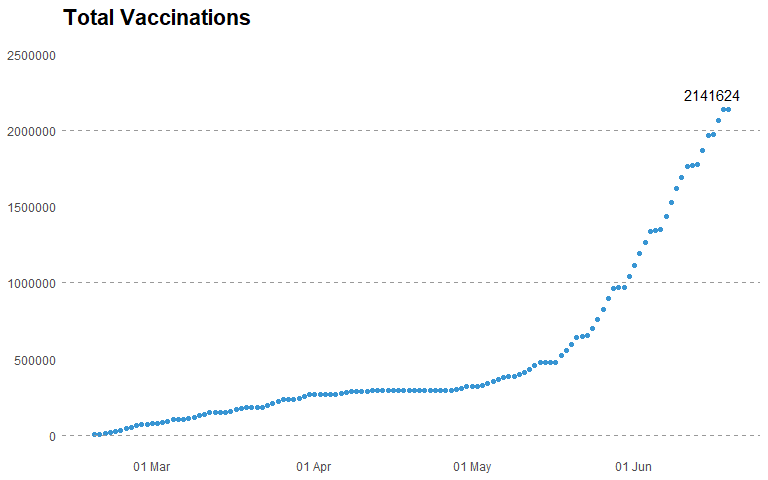

```r
plot_2_table <- sa_cases %>% select(date, vaccinated_total) %>%
  mutate(date=as.Date(date,"%d/%m/%Y")) %>%                    #mutate date column to date format
  filter(!is.na(date)) %>%
  filter(!is.na(vaccinated_total), vaccinated_total>0)         #filter unwanted values

total_vaccinations <- ggplot(data = plot_2_table, aes(x=date , y=vaccinated_total))+
  geom_point(color = "#3895D3")+
  scale_y_continuous(limits = c(0,2500000), breaks = seq(0, 2500000, by = 500000))+
  scale_x_date(limits = as.Date(c("2021-02-18","2021-06-19")), date_breaks = ("1 month"), date_labels = "%d %b")+     #displays date in required format on plot
  geom_hline(yintercept=c(0,1000000, 2000000), linetype="dashed", color="grey60")+
  geom_text(data = plot_2_table %>% filter(date == last(date)), aes(y=vaccinated_total, label = vaccinated_total), vjust=-0.7, hjust=0.8)+
  labs(title = "Total Vaccinations")+
  theme(                                                      #various theme settings
        panel.border = element_blank(),
        panel.background = element_blank(),
        panel.grid = element_blank(),                        #panel.grid.minor & panel.grid.major both removed to comply with mediahack visual
        plot.title = element_text(face="bold",size = rel(1.5)),
        plot.subtitle = element_text(colour = "grey40"),
        axis.title = element_blank(),
        axis.ticks = element_blank()
        )
total_vaccinations
```

### Plot 3: Daily Confirmed Cases

The Daily confirmed cases plot aims to indicate the number of daily positive COVID-19 cases within South Africa over a period of time. Thus the date was needed in the correct format to scale it across the x-axis. The *geom_col* and *geom_line* plots were chosen as the columns indicates the number of cases while the line could be used to plot the 7-day average. The coming of a third wave of increased daily cases can be seen with the 7-day average increasing exponentially starting in May 2021.

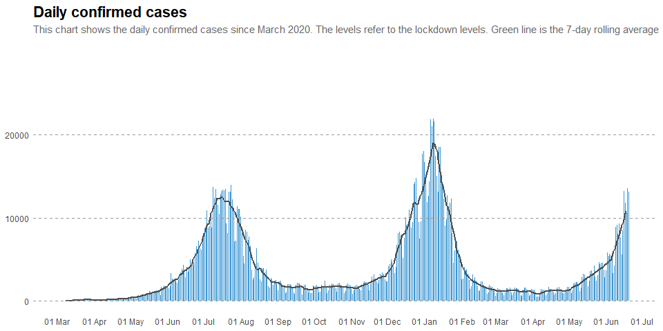

```r
plot_3_table<-sa_cases %>%
  select(date, cases_daily )%>%
  mutate(date=as.Date(date,"%d/%m/%Y"))                #mutate date column to date format

plot_three<-plot_3_table %>% filter(date>=as.Date("2020-03-01") & date<=as.Date("2021-06-21")) %>%
  ggplot(mapping = aes(y=cases_daily,x=date))+
  geom_col(width = 0.3, fill="#3895D3")+
  geom_line(aes(y=rollmean(cases_daily, 7, na.pad=TRUE)), color="grey30", size=1) +  #7 day moving average line using rollmean
  scale_y_continuous(breaks = c(0,20000,10000), limits = (c(0,30000)))+
  scale_x_date(date_breaks = "1 month",               #displays one day per month on plot
               date_labels = "%d %b")+                #displays date in required format on plot
  labs(x="Date", y="Daily Cases",                     #add labels to axis
       title="Daily confirmed cases",
       subtitle ="This chart shows the daily confirmed cases since March 2020. The levels refer to the lockdown levels. Green line is the 7-day rolling average" )+
  geom_hline(yintercept=c(0,10000,20000), linetype="dashed", color="grey60")+
  theme(                                                      #various theme settings
        panel.border = element_blank(),
        panel.background = element_blank(),
        panel.grid = element_blank(),                        #panel.grid.minor & panel.grid.major both removed to comply with mediahack visual
        plot.title = element_text(face="bold",size = rel(1.5)),
        plot.subtitle = element_text(colour = "grey40"),
        axis.title = element_blank(),
        axis.ticks = element_blank(),
        axis.text.x = element_text()
        )
plot_three
```

### Plot 4: Active Case Total by Day

The active case total by day suggests the overall daily active cases per month. The slopes in-between the spikes were especcially important to indicate the active cases over time as the level of ‘lockdown’ changes and what wave the country was in. The geom_col visual was chosen as each day would indicate a specific amount of of active cases and not the accumulation of the cases. The column graph also exceeds in telling when the country had its worse month and during which ‘lockdown’ level it took place in.

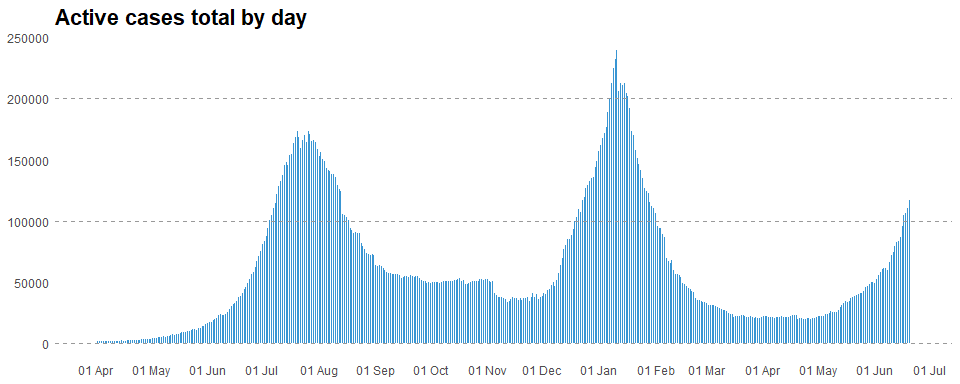

```r
plot_4_table <- sa_cases %>%  select(date, active_cases) %>%
  mutate(date=as.Date(date,"%d/%m/%Y")) %>%                   #mutate date column to date format
  filter(!is.na(date)) %>%
  filter(!is.na(active_cases))

daily_active_cases <- ggplot(data = plot_4_table, mapping = aes(x = date, y = active_cases))+
  geom_col(width = 0.4, fill="#3895D3")+
  geom_hline(yintercept=c(0,100000, 200000), linetype="dashed", color="grey60")+
  scale_x_date(limits = as.Date(c("2020-04-01","2021-06-21")), date_breaks = ("1 month"), date_labels = "%d %b")+
  labs(
       title = "Active cases total by day")+
  theme(
        axis.text.x = element_text(),
        axis.title.x = element_blank(),
        axis.title.y = element_blank(),
        axis.ticks = element_blank(),
        panel.border = element_blank(),
        panel.background = element_blank(),
        plot.title = element_text(face="bold",size = rel(1.5))
        )
daily_active_cases
```

### Plot 5: Daily Deaths

As an important figure to keep right next to the daily active cases from before, the daily deaths indicate the number of daily deaths within a specific month. As with the daily active cases, it indicates when and how many people past away within a specific month. The geom_col was again chosen as the figure of choice in order to indicate the rise and fall of daily deaths due to COVID-19.

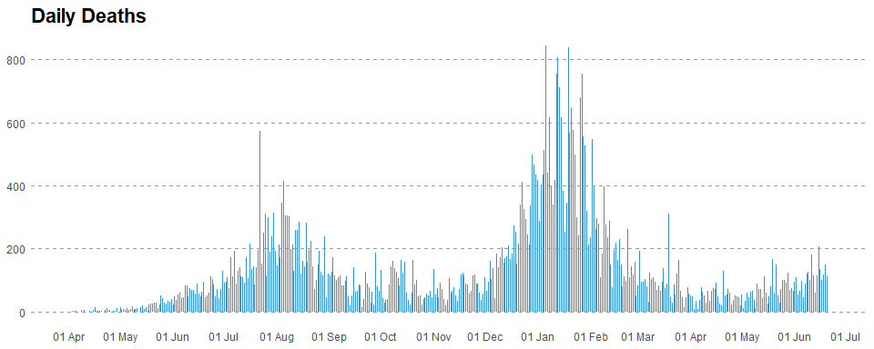

```r
plot_5_table <- sa_cases %>%
  select(date, deaths_daily)%>%
  mutate(date=as.Date(date,"%d/%m/%Y"))                                           #mutate date column to date format

daily_deaths <- ggplot(data = plot_5_table, mapping = aes(x = date, y = deaths_daily))+
  geom_col(width=0.4, fill = "#3895D3")+                                          #visual customization of columns
  geom_hline(yintercept=c(0,200, 400, 600, 800), linetype="dashed", color="grey60")+
  scale_x_date(limits = as.Date(c("2020-04-01","2021-06-21")), date_breaks = ("1 month"), date_labels = "%d %b")+
  labs(
       title = "Daily Deaths")+
  theme(
        axis.text.x = element_text(),
        axis.title = element_blank(),
        axis.ticks = element_blank(),
        panel.border = element_blank(),
        panel.background = element_blank(),
        plot.title = element_text(face="bold",size = rel(1.5))
        )
daily_deaths
```

### Plot 6: Daily Case Trends

The Daily case trends plot aims to indicate the trend of the number of daily positive COVID-19 cases across South African provinces over a period of time. The *geom_line* plot was chosen to easily compare the waves across provinces. The coming of a third wave of increased daily cases across most provinces can be seen with the line sloping up starting in May 2021. Other observations include the fact that some provinces are experiencing their third wave much earlier than others.

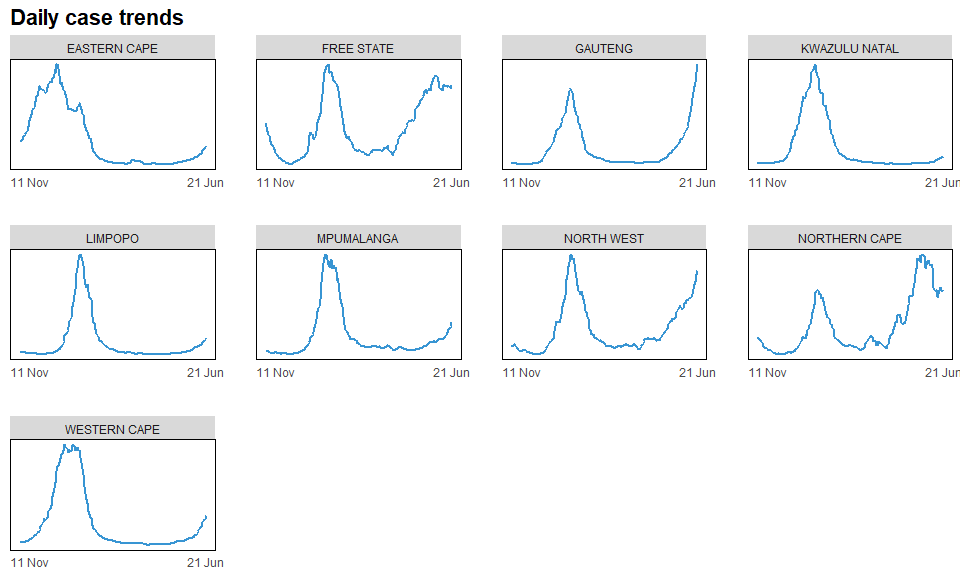

```r
plot_6_table<-province_data %>% select(date, province, cases_seven_day_average) %>%              #new table for plot six with required variables
  mutate(date=as.Date(date,"%d/%m/%Y")) %>%
  filter(province!="Unknown" & date>=as.Date("2020-10-30") & date<=as.Date("2021-06-21"))        #remove observations not needed

plot_6_table$province=toupper(plot_6_table$province)                                             #upper case all province names

plot_six<-plot_6_table %>% ggplot(mapping = aes(x=date, y=cases_seven_day_average))+
  geom_line(color="#3895D3", size=1)+
  scale_y_continuous()+
  scale_x_date(breaks = as.Date(c("2020-11-11","2021-06-21")),      #displays two selected dates
               date_labels = "%d %b")+                              #displays date in required format on plot
               #guide = guide_axis(n.dodge=2))+                     #prevents labels from overlapping
  labs(x="Date", y="Seven day average of new cases by province",    #add labels to axis
       title="Daily case trends")+
  facet_wrap(~province, scales = "free", ncol=4)+           #facet to provide each province with different plot and independent scales
  theme(
        legend.position = "right",                          #various visual customization / no legend on graph
        panel.spacing = unit(1, "cm"),                      #space panels apart
        panel.grid = element_blank(),
        panel.background = element_rect(colour = "black", size=.5, fill=NA),
        plot.title = element_text(face="bold",size = rel(1.5)),
        axis.title=element_blank(),
        axis.text.y = element_blank(),
        axis.ticks = element_blank()
        )
plot_six
```

### Plot 7: Cases vs Active Cases

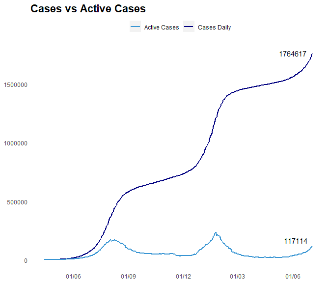

```r
plot_7_table <- sa_cases %>% mutate(date=as.Date(date,"%d/%m/%Y")) %>%
  mutate(cases_daily = cumulative_cases - cumulative_deaths) %>%
  select(date, active_cases, cases_daily)

cases_vs_active <- ggplot(data = plot_7_table, mapping= aes(x = date))+
  geom_line(method = "gam", aes(y = cases_daily, color = "Cases Daily") ,size=1)+
  geom_line(method = "gam", aes(y = active_cases,color = "Active Cases"),size=1)+
  geom_text(data = plot_7_table %>% filter(date == last(date)), aes(y = cases_daily, label = cases_daily), vjust = 0.5, hjust = 1.2)+
  geom_text(data = plot_7_table %>% filter(date == last(date)), aes(y = active_cases, label = active_cases), vjust = -0.5, hjust = 1.2)+
  scale_color_manual(values=c("Cases Daily" = "navy", "Active Cases" = "#3895D3"))+
  scale_y_continuous(breaks = c(0, 500000, 1000000, 1500000))+
  scale_x_date(limits = as.Date(c("2020-04-01","2021-06-21")), date_breaks = ("3 months"), date_labels = "%d/%m")+
  labs(title = "Cases vs Active Cases")+
  theme(
        legend.position = "top",
        legend.title = element_blank(),
        axis.text.x = element_text(hjust = 1),
        axis.title = element_blank(),
        axis.ticks = element_blank(),
        panel.border = element_blank(),
        panel.background = element_blank(),
        plot.title = element_text(face="bold",size = rel(1.5))
        )
cases_vs_active
```

### Plot 8: Total Deaths

The total deaths plot aims to indicate the cumulative number of deaths and case fatality rate over a period of time. A *geom_line* plot was chosen to visualize the increasing number of deaths and fatality rate. A rapid increase in deaths can be observed with each wave of increased infections. A challenging plot to visualize as Rstudio does not provide an easy way to plot two geoms with separate y-scales.

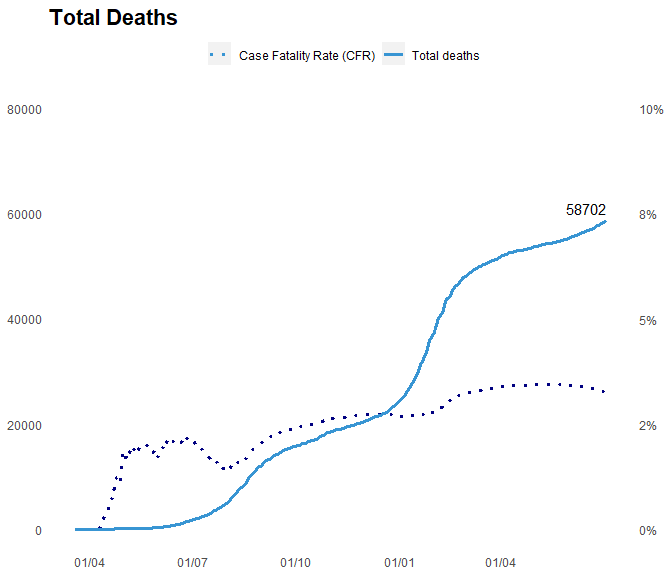

```r
plot_8_table<-sa_cases %>%
  select(date, cumulative_deaths, cumulative_cases)%>%
  mutate(date=as.Date(date,"%d/%m/%Y"), fatality_rate = cumulative_deaths/cumulative_cases*100)%>%   #calculating the case fatality rate
  filter(date>=as.Date("2020-03-01") & date<=as.Date("2021-06-21"))

factor=8000          #appropriate multiplication factor used for most accurate second axis results/ ggplot does not seem to like adding plots with separate y-scales

plot_eight<-plot_8_table %>% ggplot(mapping=aes(x=date))+
  geom_text(data = plot_8_table %>% filter(date == last(date)), aes(y=cumulative_deaths, label = cumulative_deaths),vjust = -0.5, hjust=1)+ #adding a label to the final data point
  geom_line(aes(y=fatality_rate*factor, linetype="Case Fatality Rate (CFR)"),color="navy" ,size=1.2)+       #assigning line types as in the specification
  geom_line(aes(y=cumulative_deaths, linetype="Total deaths"),color="#3895D3",size=1.2)+
  scale_linetype_manual(values=c("Case Fatality Rate (CFR)" ='dotted', "Total deaths" ='solid'))+       #associating line types with the legend
  scale_y_continuous(limits=c(0, 80000), sec.axis = sec_axis(~./factor, name = "Case Fatality Rate",
                                                             labels = function(b) { paste0(round(b, 0), "%")}))+    #proper labeling/adding % behind each value
  scale_x_date(breaks = as.Date(c("2020-04-01","2020-07-01","2020-10-01","2021-01-01","2021-04-01")),   #displays one day per month on plot
               date_labels = "%d/%m")+    #displays date in required format on plot
  labs(linetype="",
       x="Date", y="Total Deaths",    #add labels to axis
       title="Total Deaths")+
  theme(legend.position = "top",
        axis.text.x = element_text(hjust = 1),
        axis.title.x = element_blank(),
        axis.title.y = element_blank(),
        axis.ticks = element_blank(),
        panel.border = element_blank(),
        panel.background = element_blank(),
        plot.title = element_text(face="bold",size = rel(1.5))
        )

plot_eight
```

### Plot 10: Deaths by Province

The death by province visual is a representation of the aggregated number of deaths within each specific province. The use of aggregation to sum all of the daily deaths by province, was to indicate the differentiation of daily deaths between each province. This graph thus indicates the severity of COVID-19 on each specific province. The use of a bar graph is generally to measure variables between different groups and this visual is no different. Thus, the bar graph was an indication of severity.

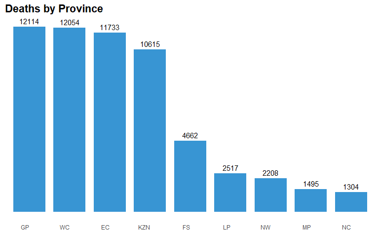

```r
plot_10_table <- aggregate(province_data$daily_deaths, by=list(province_id=province_data$province_id), F = sum)%>%  #aggregating data by unique province name
  filter(province_id!="U")%>%
  rename(total_deaths = x)

plot_ten<-plot_10_table %>%
  ggplot(mapping = aes(x=reorder(province_id,desc(total_deaths)), y=total_deaths))+  #ordering province according to total deaths
  geom_col(width = 0.8,fill="#3895D3")+
  scale_fill_continuous(trans = 'reverse')+               #reversing legend colours on continuous scale
  scale_y_continuous()+
  geom_text(aes(label = total_deaths), vjust = -0.5)+
  labs(x="Deaths", y="Province",    #add labels to axis
        title="Deaths by Province")+
  theme(
        #legend.position = "top",
        axis.text.x = element_text(hjust = 1),
        axis.text.y = element_blank(),
        axis.title.x = element_blank(),
        axis.title.y = element_blank(),
        axis.ticks = element_blank(),
        panel.border = element_blank(),
        panel.background = element_blank(),
        plot.title = element_text(face="bold",size = rel(1.5))
        )
plot_ten
```

### Plot 11: Deaths by Province per 100k

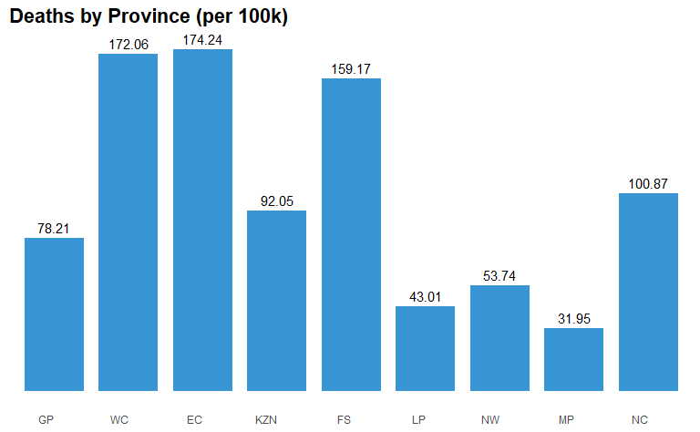

```r
plot_11_table<- aggregate(province_data$deaths_per_100k, by=list(province_id=province_data$province_id), F = max)%>%  #extract the max value per province
  filter(province_id!="U") %>%
  rename(deaths_per_100k = x)               #aggregating data by unique province name

plot_eleven<-plot_11_table %>%
  ggplot(mapping = aes(x=reorder(province_id,desc(plot_10_table$total_deaths)), y=deaths_per_100k))+ # keeping plot ten province order
  geom_col(width = 0.8, fill="#3895D3")+
  scale_fill_continuous(trans = 'reverse')+               #reversing legend colours
  scale_y_continuous()+
  geom_text(aes(label = deaths_per_100k), vjust = -0.5)+  #adding a labelled point on the plot
  labs(x="Deaths", y="Province",    #add labels to axis
      title="Deaths by Province (per 100k)")+
  theme(legend.position = "top",
        axis.text.x = element_text(hjust = 1),
        axis.text.y = element_blank(),
        axis.title = element_blank(),
        axis.ticks = element_blank(),
        panel.border = element_blank(),
        panel.background = element_blank(),
        panel.grid = element_blank(),
        plot.title = element_text(face="bold",size = rel(1.5))
        )

plot_eleven
```

### Plot BONUS

BONUS: This plot uses similar data as Plot 11 but uses it to display the data on a map of South Africa. The coordinates are linked to the capital of each province.

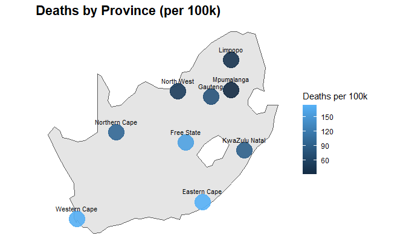

```r
plot_bonus_table<-province_data_map %>%                 #special table for bonus plot
  select(province,deaths_per_100k,Latitude,Longitude)

rnaturalearth::ne_countries(                            #rnaturalearth to select South Africa as the desired region
  scale = "small", returnclass = "sf") %>%
  select(name, continent, geometry) %>%
  filter(name == 'South Africa') ->
za
  #
map<-ggplot(data = plot_bonus_table) +                 #creating the map
  ggplot2::geom_sf(data = za) +
  geom_point(aes(x = Longitude,
                   y = Latitude,
                   colour = deaths_per_100k), size=9,
               alpha = .9)+
  geom_text(aes(Longitude, Latitude, label = province), size=3, vjust=-1.5)+
  labs(y="Province",                                   #add labels to axis
      title="Deaths by Province (per 100k)",
      colour="Deaths per 100k")+
  theme(legend.position = "right",
        axis.text = element_blank(),
        axis.title = element_blank(),
        axis.ticks = element_blank(),
        panel.border = element_blank(),
        panel.background = element_blank(),
        panel.grid = element_blank(),
        plot.title = element_text(face="bold",size = rel(1.5))
        )
map
```

### Plot 12: Prov Infections per 100,000 Population

The provincial infections per 100,000 people visual is a representation of the total number of infections within each specific province per 100,000 people. This graph thus indicates the severity of COVID-19 infections on each specific province as a comparable rate. A bar graph is generally used to measure variables between different groups and this visual is no different. Once again, the infection rate of the Northern Cape and the Free state is quite high compared to other provinces with much larger populations.

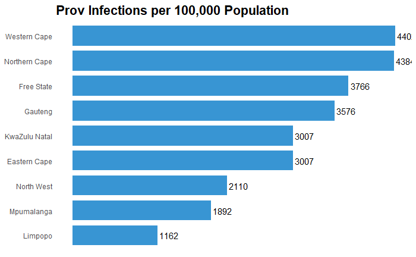

```r
plot_12_table<-province_data %>%
  select(province,cumulative_cases,population) %>%
  filter(province!="Unknown") %>%
  group_by(province) %>%
  summarise_each(funs(max)) %>%
  mutate(calc=cumulative_cases/(population/100000)) #calculating cases per 100000

plot_twelve<-plot_12_table %>%
  ggplot(mapping = aes(y=reorder(province,calc), x=calc))+ # keeping plot ten province order
  geom_col(fill="#3895D3",width = 0.8)+
  #scale_fill_continuous(trans = 'reverse')+               #reversing legend colours
  scale_x_continuous()+
  geom_text(aes(label = round(calc)), hjust=-0.1)+  #adding a labelled point on the plot
  labs(x="Cases per 100k", y="Province",    #add labels to axis
        title="Prov Infections per 100,000 Population")+
  theme(legend.position = "top",
        axis.text.x = element_blank(),
        axis.title = element_blank(),
        axis.ticks = element_blank(),
        panel.border = element_blank(),
        panel.background = element_blank(),
        panel.grid = element_blank(),
        plot.title = element_text(face="bold",size = rel(1.5))
        )
plot_twelve
```

### Plot 13: Confirmed and Active Cases by Province

A sort of a combination between plots seven and ten, the confirmed and active cases by province indicate the severity of COVID-19 on the health care infrastructure and its citizens, but at a provincial scale. The comparison between active and confirmed cases is important in terms of isolating a specific province due to their infections. Gauteng for instance is seeing quite a differentiation between its cumulative confirmed cases and its active cases. Facet was used to group confirmed and active cases by their specific province.

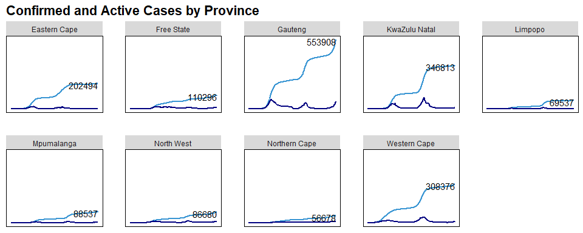

```r
plot_13_table <- province_data %>%
  filter(province!="Unknown") %>%
  mutate(date=as.Date(date,"%d/%m/%Y")) %>%
  group_by(province) %>%
  mutate(active_cases=cumulative_cases - cumulative_recoveries - cumulative_deaths) %>%
  select(date, active_cases, cumulative_cases)
con_act_cases_graph <- ggplot (data = plot_13_table, mapping = aes(x=date))+
  geom_line(method = "gam", mapping = aes( y = cumulative_cases), color="#3895D3", size=1)+
  geom_line(method = "gam", mapping= aes( y = active_cases), color="navy", size=1)+
  scale_x_date(limits = as.Date(c("2020-03-23","2021-06-21")), date_breaks = "1 day", date_labels = "%d %b %y")+
  geom_text(data = plot_13_table %>% filter(cumulative_cases == last(cumulative_cases)), aes(y = cumulative_cases, label = cumulative_cases), hjust = 1, vjust = 0.75)+
  labs(title = "Confirmed and Active Cases by Province")+
  facet_wrap(~province, ncol=5)+
  theme(legend.position = "right",      #various visual customization / no legend on graph
        panel.spacing = unit(1, "cm"),        #space panels apart
        panel.grid = element_blank(),
        panel.background = element_rect(colour = "black", size=.5, fill=NA),
        plot.title = element_text(face="bold",size = rel(1.5)),
        axis.title=element_blank(),
        axis.text = element_blank(),
        axis.ticks = element_blank()
        )

con_act_cases_graph
```

### Plot 14: Average Daily Test per Week

Average daily tests per week is an important visual in terms of the amount of tests that were done during a specific week. This visual acts as a preemptive observation to the following visual. The amount of tests and the amount of those tests that were positive are important to note in terms of when the most tests came out as positive. The horizontal column graph was used to congruently measure both the average positives and tests per week with one another. Thus, the graph indicates that when more tests are done, the higher the probability of a positive test is apparent.

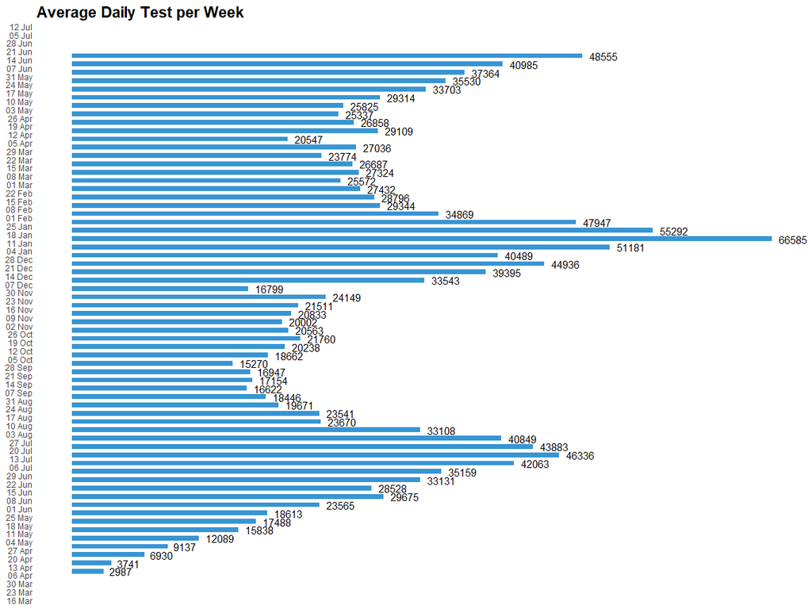

```r
plot_14_table <- sa_cases %>%
  mutate(weekly_tests = round(weekly_tests/7), digits = 1) %>%
  filter(!is.na(weekly_tests)) %>%
  mutate(date=as.Date(date,"%d/%m/%Y")) %>%
  select(date, weekly_tests)

avg_daily_test_graph <- ggplot(data = plot_14_table, mapping = aes(x = date, y = weekly_tests))+
  geom_col(fill = "#3895D3", width = 4)+
  geom_text(aes(label = weekly_tests), hjust = -0.25)+
  coord_flip()+
  scale_y_continuous()+
  scale_x_date(limits = as.Date(c("2020-04-06","2021-06-21")), date_breaks = ("1 week"), date_labels = "%d %b")+
  labs(title = "Average Daily Test per Week")+
        theme(                                #various visual customization / no legend on graph
        panel.grid = element_blank(),
        panel.background = element_blank(),
        plot.title = element_text(face="bold",size = rel(1.5)),
        axis.title = element_blank(),
        axis.ticks = element_blank(),
        axis.text.x = element_blank()
        )

avg_daily_test_graph
```

```r
NA
```

### Plot 15: Average Daily Positives per Week

As stated within the previous plot discussion, the average daily positives play a important role in terms of overall infection rate. When more tests are done, the more positive cases are noted. Thus, the column graph is once again used in parallel with the previous one to indicate the amount of positive cases per daily tests.

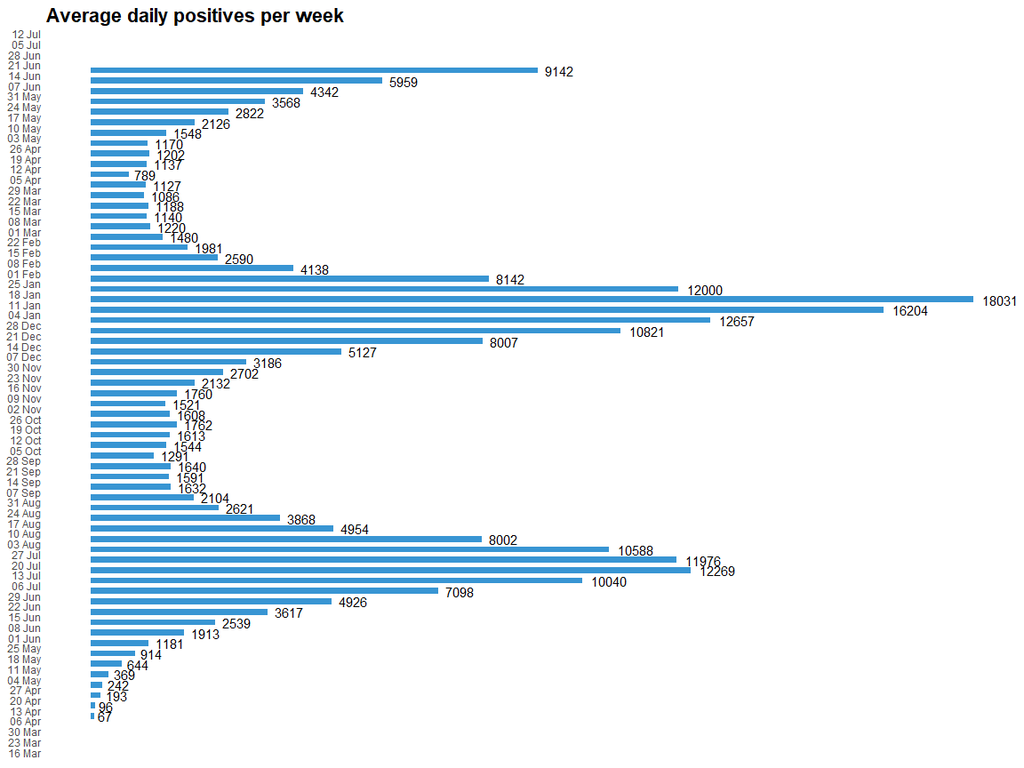

```r
plot_15_table <- sa_cases %>%
  mutate(weekly_cases = round(weekly_cases/7), digits = 1) %>%
  filter(!is.na(weekly_cases)) %>%
  mutate(date=as.Date(date,"%d/%m/%Y")) %>%
  select(date, weekly_cases)

avg_daily_pos_graph <- ggplot(data = plot_15_table, mapping = aes(x = date, y = weekly_cases))+
  geom_col(fill = "#3895D3",width = 4)+
  geom_text(aes(label = weekly_cases), hjust = -0.25)+
  coord_flip()+
  scale_y_continuous()+
  scale_x_date(limits = as.Date(c("2020-04-03","2021-06-21")), date_breaks = ("1 week"), date_labels = "%d %b")+
  labs(title = "Average daily positives per week")+
  theme(                                #various visual customization / no legend on graph
        panel.grid = element_blank(),
        panel.background = element_blank(),
        plot.title = element_text(face="bold",size = rel(1.5)),
        axis.title = element_blank(),
        axis.ticks = element_blank(),
        axis.text.x = element_blank()
        )

avg_daily_pos_graph
```

### Plot 16: No of Test per Positive case (weekly)

As with the two above-mentioned plot discussions, the number of tests per positives plot is only outcome of the both of these plots. Basically, this visual is a combination of the daily positives and daily test visuals. By dividing the average daily tests by the average positives, the data for this plot is obtainable. Again, a column graph was used to indicate an increase and decrease in positives per case for each week.

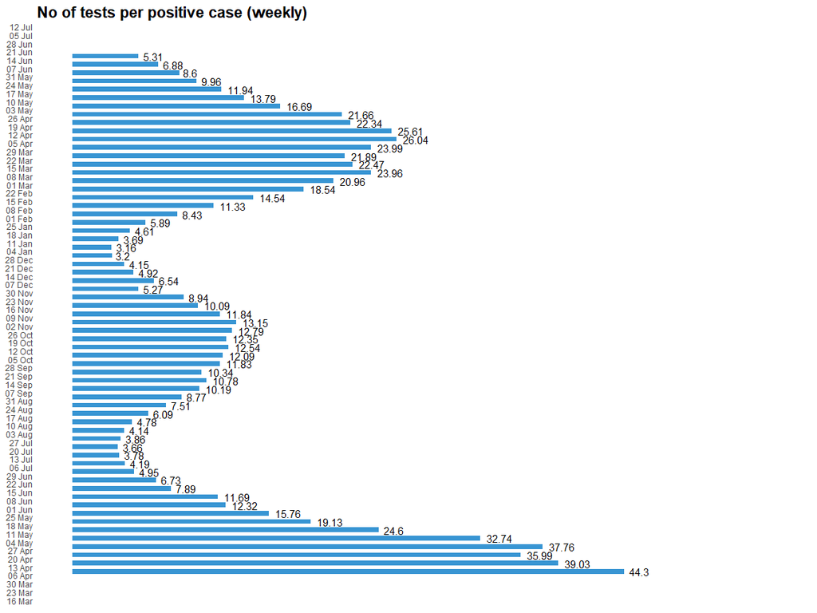

```r
plot_16_table <- sa_cases %>% mutate(weekly_tests = round(weekly_tests/weekly_cases,2)) %>%
  filter(!is.na(weekly_tests)) %>%
  mutate(date=as.Date(date,"%d/%m/%Y")) %>%
  select(date, weekly_tests)


no_tests_per_pos_graph <- ggplot(data = plot_16_table, mapping = aes(x = date, y = weekly_tests))+
  geom_col(fill = "#3895D3",width = 4)+
  geom_text(aes(label = weekly_tests), hjust = -0.25)+
  coord_flip()+
  scale_y_continuous()+
  scale_x_date(limits = as.Date(c("2020-04-03","2021-06-21")), date_breaks = ("1 week"), date_labels = "%d %b")+
  labs(title = "No of tests per positive case (weekly)")+
  theme(legend.position = "none",                                #various visual customization / no legend on graph
        panel.grid = element_blank(),
        panel.background = element_blank(),
        plot.title = element_text(face="bold",size = rel(1.5)),
        axis.title.y = element_blank(),
        axis.title.x = element_blank(),
        axis.ticks = element_blank(),
        axis.text.x = element_blank()
        )

no_tests_per_pos_graph
```

### Plot 17: Daily Tests and Positive Cases

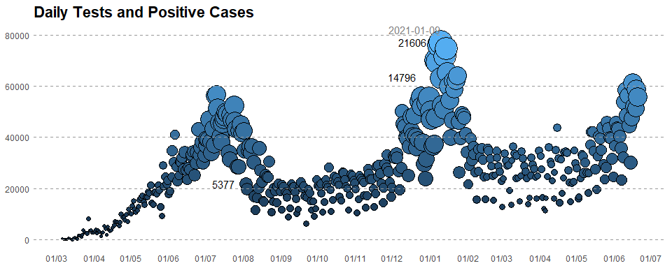

```r
plot_17_table<-sa_cases %>% select(date,tests_daily,cases_daily)%>%
  mutate(date=as.Date(date,"%d/%m/%Y")) %>%
  filter(!is.na(tests_daily)&tests_daily>=0)     #accounting for missing values and error values (e.g. negative daily tests)

plot_seventeen<-plot_17_table %>% filter(date>=as.Date("2020-03-01") & date<=as.Date("2021-06-21")) %>%
  ggplot(mapping = aes(y=tests_daily,x=date))+
  geom_point(aes(fill=tests_daily, size=cases_daily),colour="black",pch=21)+      #point plot with scaling dot size according to cases per day/ black outline

  #labels on plot
  geom_text(data = plot_17_table %>% filter(date == as.Date("2020-08-03")), aes(label = cases_daily),hjust=1.5, colour = "black")+
  geom_text(data = plot_17_table %>% filter(date == as.Date("2020-12-25")), aes(label = cases_daily),vjust = -3,hjust=1.2, colour = "black")+
  geom_text(data = plot_17_table %>% filter(date == as.Date("2021-01-09")), aes(label = date),hjust=1,vjust = -1, colour = "grey50")+
  geom_text(data = plot_17_table %>% filter(date == as.Date("2021-01-09")), aes(label = cases_daily),hjust=1.5, colour = "black")+

  scale_size_continuous (range = c(1, 12))+                                          #scale point size
  scale_y_continuous(breaks = c(0,20000,40000,60000,80000))+
  scale_x_date(date_breaks = "1 month",   #displays one day per month on plot
               date_labels = "%d/%m")+    #displays date in required format on plot
  labs(x="Date", y="Number of tests per day",    #add label names to axis
       title="Daily Tests and Positive Cases",
       vaccinated_daily = "Legend")+
  geom_hline(yintercept=c(0,20000,40000,60000,80000), linetype="dashed", color="grey60")+
  theme(legend.position = "none",      #various visual customization / no legend on graph
        axis.title = element_blank(),
        axis.ticks = element_blank(),
        panel.border = element_blank(),
        panel.background = element_blank(),
        panel.grid = element_blank(),
        plot.title = element_text(face="bold",size = rel(1.5))
        )

plot_seventeen
```

### Plot 18: Confirmed Infections (last 20 days)

The need for recently confirmed infections are probably one of the more important data analysis that one can do. This visual indicates the amount of confirmed cases over the past 20 day. This is done by aggregating the sum of each day’s cases. This will thus give a clear depiction of recent efforts and the fluctuation of cases per day. A column graph was used to measure each day’s infections with the next.

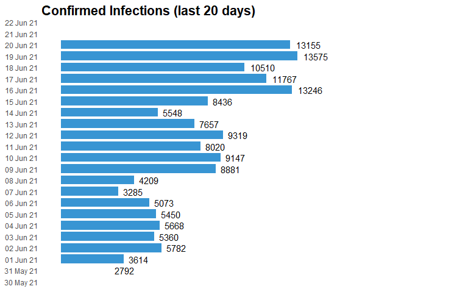

```r
plot_18_table<-aggregate(sa_cases$cases_daily, by=list(date = sa_cases$date), F = sum) %>%    #create a cumulative column
  filter(!is.na(date)) %>%
  mutate(date=as.Date(date,"%d/%m/%Y"))

confirmed_cases_20<-ggplot(data = plot_18_table, mapping = aes(x = date, y=x))+
  geom_col(fill = "#3895D3", width = 0.8)+
  geom_text(aes(label = x), hjust = -0.25)+
  coord_flip()+
  scale_y_continuous()+
  scale_x_date(limits = as.Date(c("2021-05-31","2021-06-21")), date_breaks = ("1 day"), date_labels = "%d %b %y")+
  labs(title = "Confirmed Infections (last 20 days)")+
  theme(                                #various visual customization / no legend on graph
        panel.grid = element_blank(),
        panel.background = element_blank(),
        plot.title = element_text(face="bold",size = rel(1.5)),
        axis.title.y = element_blank(),
        axis.title.x = element_blank(),
        axis.ticks = element_blank(),
        axis.text.x = element_blank()
        )
confirmed_cases_20
```

### Plot 19: Positiviy Rate: Number of Tests vs Positive Cases(%)

The Positiviy rate: number of tests vs positive cases(%) plot aims to visualize the number of daily tests and positive test rate over time as a combination *geom_col* and *geom_line* plot. An increasing trend can be observed with the rolling 7-day average line (dashed) increasing. This is in line with the expectations of a current third wave.

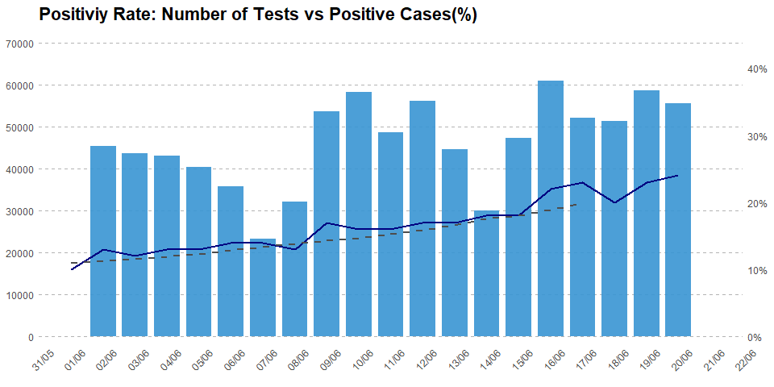

```r
plot_nineteen_table<-sa_cases %>% select(date,cases_daily, tests_daily)%>%
  mutate(date=as.Date(date,"%d/%m/%Y"), positive_rate = round(cases_daily/tests_daily*100))%>%   #calculating positive test rate
  filter(date>=as.Date("2021-05-27") & date<=as.Date("2021-06-21"))

factor=1600

plot_nineteen<-plot_nineteen_table %>%
  ggplot(mapping = aes(x=date))+
  geom_col(aes(y=tests_daily),fill="#3895D3", width = 0.8, alpha = 0.9)+    #assigning line types as in the specification
  geom_line(aes(y=positive_rate*factor),color="navy" ,size=1)+
  geom_line(aes(y=rollmean(positive_rate, 7, na.pad=T)*1500), color="grey30", size=0.8, linetype="dashed") +    #7 day average with rollmean
  scale_x_date(limits = as.Date(c("2021-06-01","2021-06-21")), date_breaks = "1 day",   #displays per day
                date_labels = "%d/%m")+
  scale_y_continuous(n.breaks=7, limits=c(0, 70000), sec.axis = sec_axis(~./1600, name = "",
                                                               labels = function(b) { paste0(round(b, 0), "%")}))+  #proper labeling/adding % behind each value
  labs(x="Date", y="Number of tests per day",    #add label names to axis
       title="Positiviy Rate: Number of Tests vs Positive Cases(%)"
       )+
  theme(legend.position = "none",      #various visual customization / no legend on graph
        panel.grid = element_blank(),
        panel.background = element_blank(),
        panel.grid.major.y = element_line(colour = "grey70", linetype = "dashed"),     #use instead of geom_hline
        plot.title = element_text(face="bold",size = rel(1.5)),
        #plot.subtitle = element_text(colour = "grey40"),
        axis.title=element_blank(),
        axis.text.x = element_text(angle = 45),
        axis.ticks = element_blank()
        )
plot_nineteen
```

### Plot 20: National Hospital Admissions

As a general preemptive indication for the health care infrastructure, the hospital admissions indicate the amount of cases that needed hospitalisation in order to recover. The week amount of cases per week is measured using the EPI-week variable in order to track each week’s admissions. Thus, because not all of the infected citizens need medical care, a line graph is best suited to see see the increase and decrease of admissions per week during a specific time frame. This could also be used to visually represent the amount of hospitalisations needed during each specific level of ‘lockdown’.

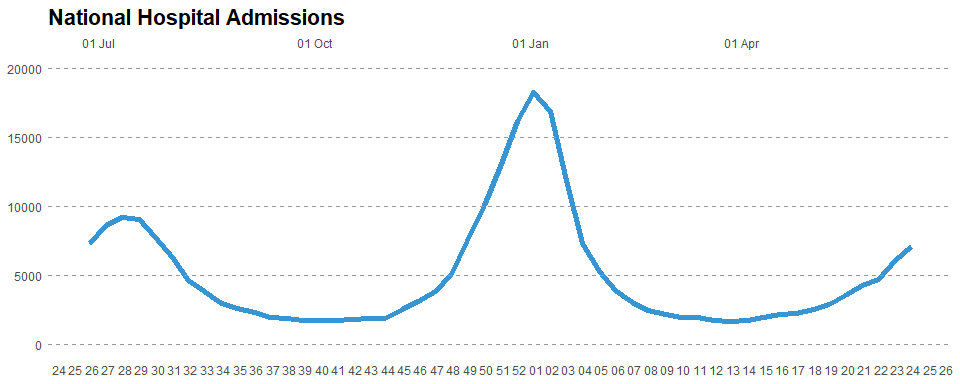

```r
plot_20_table <- sa_hospitalisations  %>%
  select(week_start, total_national_hospital_admissions, week)

hospital_add_graph <- ggplot(data = plot_20_table, mapping = aes( y = total_national_hospital_admissions, x = week_start))+
  geom_line(stat = "identity", color = "#3895D3", size=2)+
  geom_hline(yintercept=c(0,5000, 10000, 15000, 20000), linetype="dashed", color="grey60")+
  scale_y_continuous()+
  scale_x_date(breaks = as.Date(c("2020-07-01","2021-06-21")), date_breaks = "1 week", labels = scales::date_format("%W"),
               sec.axis = sec_axis(~.-1, labels = scales::date_format("%d %b")))+
  labs(title = "National Hospital Admissions")+
  theme(panel.grid = element_blank(),
        axis.title = element_blank(),
        axis.ticks = element_blank(),
        panel.border = element_blank(),
        panel.background = element_blank(),
        plot.title = element_text(face="bold",size = rel(1.5)),
        #plot.subtitle = element_text(colour = "grey60")
        )
hospital_add_graph
```

### Plot 21: Current Rt Estimates for South Africa

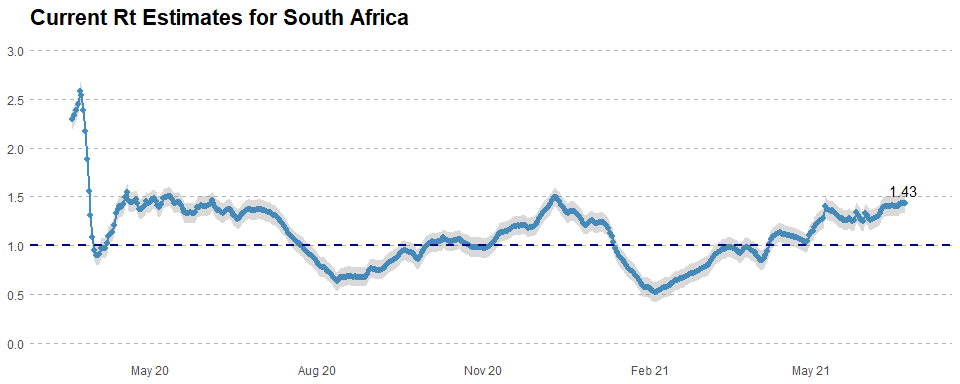

```r
plot_21_table<-sa_reproduction_rate %>%
  select(date, reproduction_rate) %>%
  mutate(date=as.Date(date,"%d/%m/%Y"))

rt_estimates_graph <- ggplot(data = plot_21_table, mapping = aes(x= date, y = reproduction_rate))+
  geom_point(color="#3895D3", size = 1.8)+
  geom_line(color="#3895D3" ,size=1)+
  geom_ribbon(mapping = aes(ymin = plot_21_table$reproduction_rate -0.1,                                                 #used for standard deviation
                            ymax = plot_21_table$reproduction_rate +0.1), alpha = 0.25, fill = "grey40")+
  geom_text(data = plot_21_table %>% filter(date == as.Date("2021-06-21")), aes(y = reproduction_rate,
                                                                                label = reproduction_rate), vjust=-0.6)+  #label value on last known date
  scale_y_continuous(limits = c(0.0, 3.0), breaks = seq(0, 3.0, by = 0.5))+
  scale_x_date(breaks = as.Date(c("2020-03-19","2021-06-21")),date_breaks = ("3 months"), date_labels = "%b %y", expand = c(0.05,0))+
  geom_hline(yintercept = 1, linetype = "dashed", color = "navy", size = 0.8)+
  labs(title = "Current Rt Estimates for South Africa")+
  theme(
        panel.grid = element_blank(),
        axis.title.x = element_blank(),
        axis.title.y = element_blank(),
        axis.ticks = element_blank(),
        panel.border = element_blank(),
        panel.grid.major.y = element_line(colour = "grey70", linetype = "dashed", size=0.5),
        panel.background = element_blank(),
        plot.title = element_text(face="bold",size = rel(1.5)),
        plot.subtitle = element_text(colour = "grey40")
        )
rt_estimates_graph
```

### Plot 22: Excess Deaths

The Excess deaths plot aims to visualize the number of excess deaths over time as a *geom_bar* plot. Each bar includes the cumulative excess deaths from May 2020 and shows weekly increments as differences between them. An increasing trend can be observed as we are in the third wave of infections. No excess death data on SAMRC after the 13th of June at the time of writing.

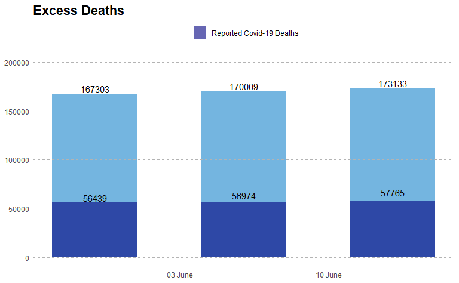

```r
excess_deaths<-excess_deaths %>%
  mutate(cum_excess_deaths=cumsum(RSA))    #adding a cumulative column to national excess_deaths

plot_22_table<- merge(excess_deaths, sa_cases, by = "date")%>%
  select(date,cum_excess_deaths, cumulative_deaths) %>%
  mutate(date=as.Date(as.character(date),"%d/%m/%Y")) %>%
  filter(date>=as.Date("2021-05-30"))
  #pivot_longer(c(`cumulative_deaths`,`cum_excess_deaths`), names_to = "type", values_to = "deaths")

plot_22<-plot_22_table %>%ggplot(mapping = aes(x = date, y = cum_excess_deaths)) +
  geom_bar(aes(y=cum_excess_deaths), stat="identity", position ="identity", fill="#3895D3", width = 4, alpha=0.7)+
  geom_bar(aes(y=cumulative_deaths, fill="Reported Covid-19 Deaths"), stat="identity", position ="identity", width = 4, alpha=0.6)+
  scale_fill_manual(values=c("Reported Covid-19 Deaths" ="navy"))+                        #adding legend labels based off color of bars
  scale_x_date(date_breaks = "7 days",   #displays one day per month on plot
               date_labels = "%d %B")+
  scale_y_continuous(limits=c(0,200000))+
  labs(x="Date", y="Deaths",    #add labels to axis
       title="Excess Deaths")+
  geom_text(aes(label = cum_excess_deaths), position=position_dodge(width=0.9), vjust=-0.25)+
  geom_text(aes(label = cumulative_deaths), position=position_dodge(width=0.9), vjust=15)+
  geom_hline(yintercept=c(0,100000,200000), linetype="dashed", color="grey70")+
  theme_minimal()+
  theme(legend.position = "top",      #various visual customization / no legend on graph
        legend.title = element_blank(),
        panel.grid = element_blank(),
        plot.title = element_text(face="bold",size = rel(1.5)),
        #plot.subtitle = element_text(colour = "grey60"),
        axis.title=element_blank(),
        axis.ticks = element_blank()
        )
plot_22
```

### Plot 23: Excess Deaths(Provinces)

The Excess deaths per province plot aims to visualize the number of excess deaths per province over time as a *geom_bar* plot. Each bar includes the cumulative excess deaths from May 2020 and shows weekly increments as differences between them. As stated previously, an increasing trend can be observed as we are in the third wave of infections. Covid-19 related deaths account for the bulk of the excess deaths in the Western Cape. It is the only province where Covid-19 deaths are observed to account for the majority of excess deaths.

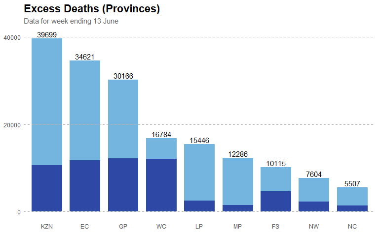

```r
province_data_merge<-province_data %>% select(province_id,daily_deaths) %>%      #gathering data from first data set
  group_by(province_id) %>%                                                      #aggregating deaths by province
  summarise_each(funs(sum)) %>%
  filter(province_id!="U") %>%
  rename(province = province_id, covid_deaths=daily_deaths)

plot_23_table<- excess_deaths %>%                                                # gathering data from second data set
  pivot_longer(c(`EC`,`FS`,`GP`,`KZN`,`LP`,`MP`,`NC`,`NW`,`WC`), names_to = "province", values_to = "deaths") %>%    #pivoting
  select(province,deaths)%>%
  group_by(province) %>% summarise_each(funs(sum))

plot_23_table<- merge(plot_23_table, province_data_merge, by = "province")        #merging province_data and excess_deaths data


plot_23<-plot_23_table %>%ggplot(mapping = aes(x=reorder(province,desc(deaths)), y =deaths))+
  geom_bar(aes(y=deaths), stat="identity", position ="identity", fill="#3895D3", width = 0.8, alpha=0.7)+
  geom_bar(aes(y=covid_deaths), stat="identity", position ="identity",  fill="navy",width = 0.8, alpha=0.6)+
  scale_y_continuous(breaks=c(0,20000,40000))+
  labs(x="Province", y="Deaths",    #add labels to axis
       title="Excess Deaths (Provinces)",
       subtitle = "Data for week ending 13 June")+
  geom_hline(yintercept=c(0,20000,40000), linetype="dashed", color="grey70")+
  geom_text(aes(label = deaths), position=position_dodge(width=0.9), vjust=-0.25)+
  theme(legend.position = "none",      #various visual customization / no legend on graph
        panel.grid = element_blank(),
        panel.background = element_blank(),
        plot.title = element_text(face="bold",size = rel(1.5)),
        plot.subtitle = element_text(colour = "grey40"),
        axis.title=element_blank(),
        axis.ticks = element_blank()
        )
plot_23
```

### Plot 24: Excess Deaths(Metros)

The Excess deaths by metro plot aims to visualize the number of excess deaths per metro over time as a *geom_bar* plot. Each bar includes the cumulative excess deaths from May 2020 and shows weekly increments as differences between them. At the time of writing, no data could be found on Covid-19 deaths within specific metros.

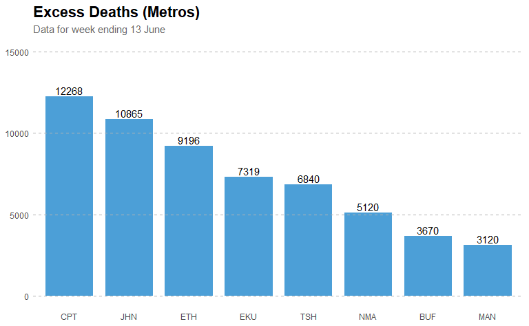

```r
plot_24_table<- excess_deaths %>%
  pivot_longer(c(`BUF`,`CPT`,`EKU`,`ETH`,`JHN`,`MAN`,`NMA`,`TSH`), names_to = "metro", values_to = "deaths") %>%    #pivoting
  select(metro,deaths) %>%
  filter(deaths>=0) %>%
  group_by(metro) %>%                                                      #aggregating deaths by metro
  summarise_each(funs(sum))

plot_24<-plot_24_table %>%ggplot(mapping = aes(x=reorder(metro,desc(deaths)), y =deaths))+
  geom_bar(aes(y=deaths), stat="identity", position ="identity", fill="#3895D3", width = 0.8, alpha=0.9)+
  #geom_bar(aes(y=covid_deaths), stat="identity", position ="identity",  fill="navy",width = 0.8, alpha=0.6)+
  scale_y_continuous(limit=c(0,15000))+
  labs(x="Metro", y="Deaths",    #add labels to axis
       title="Excess Deaths (Metros)",
       subtitle = "Data for week ending 13 June")+
  geom_hline(yintercept=c(0,5000,10000,15000), linetype="dashed", color="grey70")+
  geom_text(aes(label = deaths), position=position_dodge(width=0.9), vjust=-0.25)+
  theme(legend.position = "none",      #various visual customization / no legend on graph
        panel.grid = element_blank(),
        panel.background = element_blank(),
        plot.title = element_text(face="bold",size = rel(1.5)),
        plot.subtitle = element_text(colour = "grey40"),
        axis.title=element_blank(),
        axis.ticks = element_blank()
        )
plot_24
```

### Plot 25: New daily confirmed Covid-19 cases: 7-day average

The new daily confirmed Covid-19 cases: 7-day average plot aims to visualize the number of positive Covid-19 cases per world region over time as a *geom_line* plot. Each line represents a different region/continent. The line plot is useful for comparison across different regions and shows the different waves as well as what regions are leading or lagging in terms of the next wave of increased infections. Europe seems to be leading the waves while Asia was hardest hit by the third wave. As a lagging region, Africa is only now beginning to experience the effects of the third wave.

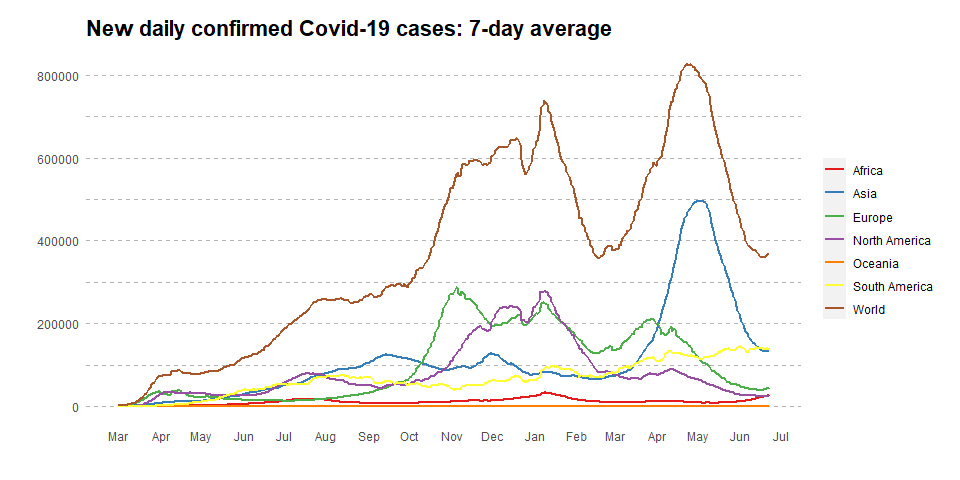

```r
plot_25_table<-continents_daily_cases %>%
  mutate(date=as.Date(as.character(date),"%d/%m/%Y")) %>%
  filter(date>=as.Date("2020-02-13"))                        #from this date - one day before the first reported case in Africa

plot_25<-plot_25_table %>%
  ggplot(mapping = aes(x=date,y=rollmean(new_cases,7,na.pad = T)))+
  geom_line(aes(colour=location), size=1)+
  scale_x_date(limits = as.Date(c("2020-03-01","2021-06-22")), date_breaks = "1 months",   #displays per day
                date_labels = "%b")+
  scale_y_continuous(labels = function(x) format(x, scientific = F))+            #prevent y-axis from showing values in scientific format
  scale_colour_brewer(palette = "Set1")+                                        # line colour customization / easily distinguishable
  labs(x="Date", y="New daily cases",                                            #add labels to axis
       title="New daily confirmed Covid-19 cases: 7-day average")+
  theme(legend.position = "right",      #various visual customization / no legend on graph
        legend.title = element_blank(),
        panel.grid = element_blank(),
        panel.background = element_blank(),
        panel.grid.major.y = element_line(colour = "grey70", linetype = "dashed"),     #use instead of geom_hline
        panel.grid.minor.y = element_line(colour = "grey70", linetype = "dashed"),     #use instead of geom_hline
        plot.margin=unit(c(0.5,0.5,1,1),"cm"),
        plot.title = element_text(face="bold",size = rel(1.5)),
        #plot.subtitle = element_text(colour = "grey60"),
        axis.title=element_blank(),
        axis.ticks = element_blank()
        )
plot_25
```

# **Section 3**

## Reflection

Upon completion of the above-mentioned visualizations, the rewarding nature of representing data in such a fashion becomes apparent. With a limited background of coding within the data analysis field, the difficulties we faced were mainly wrangling and cleaning the data sets using Rstudio. Even after two weeks of learning and practice during the data analysis block, we soon realized we were not yet experts in the field. This was because we still lacked the experience and forward-thinking needed to make sure the correct data is sorted and cleaned in order to successfully re-create all of the visualizations. Forward-thinking means that we had to think ahead of what the final visual would look like. We had to ensure that the data is not only accurate and up to date, but also wrangled and processed in such a way that no errors will be thrown when the visual is constructed. Thus, to reflect, the main purpose of this assignment was to re-create as many visualizations as possible, which we did in a way that we both find satisfactory. Although some plots – such as the doubling rates visual – offered more of a challenge, both of us knew what to do, but the how and the execution were at times a struggle. That being said, the fulfillment we received when a plot was accurately visualized made the late night struggles worth it.

## Conclusion

After sifting and searching through vast amounts of data sets and then wrangling and cleaning the data into a usable state, the need for and the importance of data analysis becomes apparent. Not only do these methods (i.e., tidying and transforming) optimize the data sets for further use, but they also encapsulate on the bigger organisational picture. Ensuring complete and non-redundant data is something that all organisations should put vast amounts of resources into. Furthermore, the more complete data is stored, the higher the probability to ensure more accurate data analytics and further increases the timeliness of said analytics. This assignment was a clear indication that data needs to be as complete as possible in order to accurately represent it in a visual fashion to those who make the important decisions. The visualization of data is thus only the reward of successfully cleaning and wrangling data.